# Table of Contents

```python
%%javascript
$.getScript('https://kmahelona.github.io/ipython_notebook_goodies/ipython_notebook_toc.js')
```

```python
from IPython.display import HTML
HTML('''<script>
code_show_err=false;
function code_toggle_err() {
 if (code_show_err){
 $('div.output_stderr').hide();
 } else {
 $('div.output_stderr').show();
 }
 code_show_err = !code_show_err
}
$( document ).ready(code_toggle_err);
</script>
To toggle on/off output_stderr, click <a href="javascript:code_toggle_err()">here</a>.''')
```

To toggle on/off output_stderr, click here.

# Classification With Bank Marketing Data

# Author: Andrew Barlow

## Import Packages

```python
%matplotlib inline
import numpy as np
import matplotlib.pyplot as plt
import pandas as pd
from sklearn import preprocessing
from sklearn.model_selection  import train_test_split, cross_val_score, KFold
from sklearn.model_selection import GridSearchCV
from sklearn.metrics import accuracy_score, precision_score, recall_score, f1_score
from sklearn.metrics import roc_curve, auc, confusion_matrix, classification_report
import time
```

## Read In Data

```python
# A cleaned version of the dataset was found on Git-Hub
# This data comes from the UCI Machine Learning Repository
# Link to data: https://archive.ics.uci.edu/ml/datasets/Bank+Marketing
Bank = pd.read_csv("https://raw.githubusercontent.com/MAJgautam/Moneyballing-Bank-Marketing/master/data/bank.csv")
```

```python
Bank.head(5)
```

|  | age | job | marital | education | default | housing | loan | contact | month | day_of_week | ... | campaign | pdays | previous | poutcome | emp.var.rate | cons.price.idx | cons.conf.idx | euribor3m | nr.employed | y |
| --- | --- | --- | --- | --- | --- | --- | --- | --- | --- | --- | --- | --- | --- | --- | --- | --- | --- | --- | --- | --- | --- |
| 0 | 56 | housemaid | married | basic.4y | no | no | no | telephone | may | mon | ... | 1 | 999 | 0 | nonexistent | 1.1 | 93.994 | -36.4 | 4.857 | 5191.0 | no |
| 1 | 57 | services | married | high.school | NaN | no | no | telephone | may | mon | ... | 1 | 999 | 0 | nonexistent | 1.1 | 93.994 | -36.4 | 4.857 | 5191.0 | no |
| 2 | 37 | services | married | high.school | no | yes | no | telephone | may | mon | ... | 1 | 999 | 0 | nonexistent | 1.1 | 93.994 | -36.4 | 4.857 | 5191.0 | no |
| 3 | 40 | admin. | married | basic.6y | no | no | no | telephone | may | mon | ... | 1 | 999 | 0 | nonexistent | 1.1 | 93.994 | -36.4 | 4.857 | 5191.0 | no |
| 4 | 56 | services | married | high.school | no | no | yes | telephone | may | mon | ... | 1 | 999 | 0 | nonexistent | 1.1 | 93.994 | -36.4 | 4.857 | 5191.0 | no |

5 rows × 21 columns

```python
# Examine the number of observations and features
Bank.shape
```

```
(41188, 21)
```

```python
# Check column names
Bank.columns
```

```
Index(['age', 'job', 'marital', 'education', 'default', 'housing', 'loan',
       'contact', 'month', 'day_of_week', 'duration', 'campaign', 'pdays',
       'previous', 'poutcome', 'emp.var.rate', 'cons.price.idx',
       'cons.conf.idx', 'euribor3m', 'nr.employed', 'y'],
      dtype='object')
```

```python
# Rename our target variable
# Our target variable represents whether or not a customer has subscribed to a term deposit
Bank.rename(columns = {'y':'Subscribed'}, inplace = True)
```

## Set Target Variable as Subscribed and Move to First Column

```python
# designate target variable name as Subscribed
targetName = 'Subscribed'
targetSeries = Bank[targetName]
# remove target from current location and insert in collum 0
del Bank[targetName]
Bank.insert(0, targetName, targetSeries)
#reprint dataframe and see target is in position 0
Bank.head(10)
```

|  | Subscribed | age | job | marital | education | default | housing | loan | contact | month | ... | duration | campaign | pdays | previous | poutcome | emp.var.rate | cons.price.idx | cons.conf.idx | euribor3m | nr.employed |
| --- | --- | --- | --- | --- | --- | --- | --- | --- | --- | --- | --- | --- | --- | --- | --- | --- | --- | --- | --- | --- | --- |
| 0 | no | 56 | housemaid | married | basic.4y | no | no | no | telephone | may | ... | 261 | 1 | 999 | 0 | nonexistent | 1.1 | 93.994 | -36.4 | 4.857 | 5191.0 |
| 1 | no | 57 | services | married | high.school | NaN | no | no | telephone | may | ... | 149 | 1 | 999 | 0 | nonexistent | 1.1 | 93.994 | -36.4 | 4.857 | 5191.0 |
| 2 | no | 37 | services | married | high.school | no | yes | no | telephone | may | ... | 226 | 1 | 999 | 0 | nonexistent | 1.1 | 93.994 | -36.4 | 4.857 | 5191.0 |
| 3 | no | 40 | admin. | married | basic.6y | no | no | no | telephone | may | ... | 151 | 1 | 999 | 0 | nonexistent | 1.1 | 93.994 | -36.4 | 4.857 | 5191.0 |
| 4 | no | 56 | services | married | high.school | no | no | yes | telephone | may | ... | 307 | 1 | 999 | 0 | nonexistent | 1.1 | 93.994 | -36.4 | 4.857 | 5191.0 |
| 5 | no | 45 | services | married | basic.9y | NaN | no | no | telephone | may | ... | 198 | 1 | 999 | 0 | nonexistent | 1.1 | 93.994 | -36.4 | 4.857 | 5191.0 |
| 6 | no | 59 | admin. | married | professional.course | no | no | no | telephone | may | ... | 139 | 1 | 999 | 0 | nonexistent | 1.1 | 93.994 | -36.4 | 4.857 | 5191.0 |
| 7 | no | 41 | blue-collar | married | NaN | NaN | no | no | telephone | may | ... | 217 | 1 | 999 | 0 | nonexistent | 1.1 | 93.994 | -36.4 | 4.857 | 5191.0 |
| 8 | no | 24 | technician | single | professional.course | no | yes | no | telephone | may | ... | 380 | 1 | 999 | 0 | nonexistent | 1.1 | 93.994 | -36.4 | 4.857 | 5191.0 |
| 9 | no | 25 | services | single | high.school | no | yes | no | telephone | may | ... | 50 | 1 | 999 | 0 | nonexistent | 1.1 | 93.994 | -36.4 | 4.857 | 5191.0 |

10 rows × 21 columns

## EDA on Target and Features

```python
# Bank.info()
```

```python
# Find the sum of missing values
print(Bank.isnull().sum())
```

```
Subscribed           0
age                  0
job                330
marital             80
education         1731
default           8597
housing            990
loan               990
contact              0
month                0
day_of_week          0
duration             0
campaign             0
pdays                0
previous             0
poutcome             0
emp.var.rate         0
cons.price.idx       0
cons.conf.idx        0
euribor3m            0
nr.employed          0
dtype: int64
```

To handle the missing values I have chosen to drop the rows in which a missing value is present. This is typically not our first choice due to the fact that we want to preserve the other present features for each observation that has a missing value in one or more columns. Since the missing values lie in features that are categorical, we can not impute by the mean or median. Removing the rows with missing values will also reduce the size of our data set, which will be helpful when we run models such as SVM.

```python
# Drop all rows with a missing value
Bank.dropna(inplace=True)
```

```python
# Examine the new shape of the dataframe
Bank.shape
```

```
(30488, 21)
```

```
Subscribed
no     26629
yes     3859
dtype: int64
```

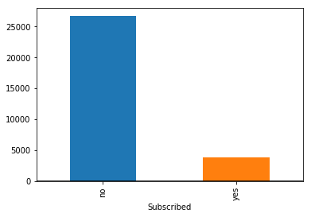

```python
# This chunk creates a bar chart to examine class balance
groupby = Bank.groupby(targetName)
targetEDA=groupby[targetName].aggregate(len)
plt.figure()
targetEDA.plot(kind='bar', grid=False)
plt.axhline(0, color='k')

Bank.groupby('Subscribed').size() # Prints the count of each class
```

We observe that the classes of our target variable 'Subscribed' are not balanced, as the number of customers who did not subscribe greatly outweighs the number of customers who chose to subscribe. This is important when evaluating the predictive accuracy of our classification models. If we guess 'no' for all customers then the naive estimate will be 87.34% accurate, and if we guess 'yes' for all customers the naive estimate will be 12.65% accurate. We will take this into account when interpreting the precision and recall of the models.

```python
# Descriptive statistics on all numeric features
Bank.describe()
```

|  | age | duration | campaign | pdays | previous | emp.var.rate | cons.price.idx | cons.conf.idx | euribor3m | nr.employed |
| --- | --- | --- | --- | --- | --- | --- | --- | --- | --- | --- |
| count | 30488.000000 | 30488.000000 | 30488.000000 | 30488.000000 | 30488.000000 | 30488.000000 | 30488.000000 | 30488.000000 | 30488.000000 | 30488.000000 |
| mean | 39.030012 | 259.484092 | 2.521451 | 956.332295 | 0.194273 | -0.071510 | 93.523311 | -40.602263 | 3.459938 | 5160.813409 |
| std | 10.333529 | 261.714262 | 2.720150 | 201.373292 | 0.522788 | 1.610399 | 0.585374 | 4.789249 | 1.777231 | 75.158065 |
| min | 17.000000 | 0.000000 | 1.000000 | 0.000000 | 0.000000 | -3.400000 | 92.201000 | -50.800000 | 0.634000 | 4963.600000 |
| 25% | 31.000000 | 103.000000 | 1.000000 | 999.000000 | 0.000000 | -1.800000 | 93.075000 | -42.700000 | 1.313000 | 5099.100000 |
| 50% | 37.000000 | 181.000000 | 2.000000 | 999.000000 | 0.000000 | 1.100000 | 93.444000 | -41.800000 | 4.856000 | 5191.000000 |
| 75% | 45.000000 | 321.000000 | 3.000000 | 999.000000 | 0.000000 | 1.400000 | 93.994000 | -36.400000 | 4.961000 | 5228.100000 |
| max | 95.000000 | 4918.000000 | 43.000000 | 999.000000 | 7.000000 | 1.400000 | 94.767000 | -26.900000 | 5.045000 | 5228.100000 |

# Preprocessing Features of the Data

## Z-Score Normalization

```python
# We will start with normalizing the numeric features
# This will be accomplished by Z-Score Normalization

from scipy.stats import zscore

# Define the numeric columns
numeric_cols = Bank.select_dtypes(include=[np.number]).columns
```

```python
# Apply Z-Score Function
ZScore = Bank[numeric_cols].apply(zscore)
```

```python
ZScore.head(5)
```

|  | age | duration | campaign | pdays | previous | emp.var.rate | cons.price.idx | cons.conf.idx | euribor3m | nr.employed |
| --- | --- | --- | --- | --- | --- | --- | --- | --- | --- | --- |
| 0 | 1.642253 | 0.005792 | -0.559335 | 0.211887 | -0.371616 | 0.727477 | 0.804095 | 0.877451 | 0.786102 | 0.401648 |
| 2 | -0.196452 | -0.127944 | -0.559335 | 0.211887 | -0.371616 | 0.727477 | 0.804095 | 0.877451 | 0.786102 | 0.401648 |
| 3 | 0.093870 | -0.414520 | -0.559335 | 0.211887 | -0.371616 | 0.727477 | 0.804095 | 0.877451 | 0.786102 | 0.401648 |
| 4 | 1.642253 | 0.181559 | -0.559335 | 0.211887 | -0.371616 | 0.727477 | 0.804095 | 0.877451 | 0.786102 | 0.401648 |
| 6 | 1.932575 | -0.460373 | -0.559335 | 0.211887 | -0.371616 | 0.727477 | 0.804095 | 0.877451 | 0.786102 | 0.401648 |

```python
# Drop Un-Normalized Columns
Bank = Bank.drop(Bank.columns[[1, 11, 12, 13, 14, 16, 17, 18, 19, 20]], axis=1)
```

```python
# Join the Z-Score columns with the Bank DF columns
Bank = pd.concat([Bank,ZScore], axis=1)
```

```python
# Check the results
Bank.head(5)
```

|  | Subscribed | job | marital | education | default | housing | loan | contact | month | day_of_week | ... | age | duration | campaign | pdays | previous | emp.var.rate | cons.price.idx | cons.conf.idx | euribor3m | nr.employed |
| --- | --- | --- | --- | --- | --- | --- | --- | --- | --- | --- | --- | --- | --- | --- | --- | --- | --- | --- | --- | --- | --- |
| 0 | no | housemaid | married | basic.4y | no | no | no | telephone | may | mon | ... | 1.642253 | 0.005792 | -0.559335 | 0.211887 | -0.371616 | 0.727477 | 0.804095 | 0.877451 | 0.786102 | 0.401648 |
| 2 | no | services | married | high.school | no | yes | no | telephone | may | mon | ... | -0.196452 | -0.127944 | -0.559335 | 0.211887 | -0.371616 | 0.727477 | 0.804095 | 0.877451 | 0.786102 | 0.401648 |
| 3 | no | admin. | married | basic.6y | no | no | no | telephone | may | mon | ... | 0.093870 | -0.414520 | -0.559335 | 0.211887 | -0.371616 | 0.727477 | 0.804095 | 0.877451 | 0.786102 | 0.401648 |
| 4 | no | services | married | high.school | no | no | yes | telephone | may | mon | ... | 1.642253 | 0.181559 | -0.559335 | 0.211887 | -0.371616 | 0.727477 | 0.804095 | 0.877451 | 0.786102 | 0.401648 |
| 6 | no | admin. | married | professional.course | no | no | no | telephone | may | mon | ... | 1.932575 | -0.460373 | -0.559335 | 0.211887 | -0.371616 | 0.727477 | 0.804095 | 0.877451 | 0.786102 | 0.401648 |

5 rows × 21 columns

```python
# This line shows that we now have 11 categorical features and 10 Normalized numerical features
# Bank.info()
```

## Convert Target to Numeric and Create Dummy Variables

```python
# This code turns a text target into numeric so some scikit learn alogrythms can process it
le_dep = preprocessing.LabelEncoder()
# to convert Subscribe into numbers
Bank['Subscribed'] = le_dep.fit_transform(Bank['Subscribed'])
```

```python
# Creates dummies of any categorical feature
for col in Bank.columns[1:]:
	attName = col
	dType = Bank[col].dtype
	missing = pd.isnull(Bank[col]).any()
	uniqueCount = len(Bank[attName].value_counts(normalize=False))
	# discretize (create dummies)
	if dType == object:
		Bank = pd.concat([Bank, pd.get_dummies(Bank[col], prefix=col)], axis=1)
		del Bank[attName]
```

```python
# Observe the new feature space
Bank.shape
```

```
(30488, 58)
```

```python
Bank.tail(5)
```

|  | Subscribed | age | duration | campaign | pdays | previous | emp.var.rate | cons.price.idx | cons.conf.idx | euribor3m | ... | month_oct | month_sep | day_of_week_fri | day_of_week_mon | day_of_week_thu | day_of_week_tue | day_of_week_wed | poutcome_failure | poutcome_nonexistent | poutcome_success |
| --- | --- | --- | --- | --- | --- | --- | --- | --- | --- | --- | --- | --- | --- | --- | --- | --- | --- | --- | --- | --- | --- |
| 41183 | 1 | 3.287410 | 0.284727 | -0.559335 | 0.211887 | -0.371616 | -0.638666 | 2.12464 | -2.129332 | -1.368408 | ... | 0 | 0 | 1 | 0 | 0 | 0 | 0 | 0 | 1 | 0 |
| 41184 | 0 | 0.674513 | 0.471957 | -0.559335 | 0.211887 | -0.371616 | -0.638666 | 2.12464 | -2.129332 | -1.368408 | ... | 0 | 0 | 1 | 0 | 0 | 0 | 0 | 0 | 1 | 0 |
| 41185 | 0 | 1.642253 | -0.269321 | -0.191702 | 0.211887 | -0.371616 | -0.638666 | 2.12464 | -2.129332 | -1.368408 | ... | 0 | 0 | 1 | 0 | 0 | 0 | 0 | 0 | 1 | 0 |
| 41186 | 1 | 0.480965 | 0.697398 | -0.559335 | 0.211887 | -0.371616 | -0.638666 | 2.12464 | -2.129332 | -1.368408 | ... | 0 | 0 | 1 | 0 | 0 | 0 | 0 | 0 | 1 | 0 |
| 41187 | 0 | 3.384184 | -0.078270 | 0.175930 | 0.211887 | 1.541237 | -0.638666 | 2.12464 | -2.129332 | -1.368408 | ... | 0 | 0 | 1 | 0 | 0 | 0 | 0 | 1 | 0 | 0 |

5 rows × 58 columns

## Randomly Split the Data into Training and Test Sets

```python
# Split dataset into 70% training and 30% testing
features_train, features_test, target_train, target_test = train_test_split(
    Bank.iloc[:,1:].values, Bank.iloc[:,0].values, test_size=0.30, random_state=0)
```

```python
# Displays the shape of our training and testing sets
print(features_test.shape)
print(features_train.shape)
print(target_test.shape)
print(target_train.shape)
```

```
(9147, 57)
(21341, 57)
(9147,)
(21341,)
```

# Decision Tree Classification Model

## DT #1

```python
# Decision Tree train model. Call up my model and name it clf
from sklearn import tree
clf_dt1 = tree.DecisionTreeClassifier(criterion='entropy',class_weight="balanced")
#Fit clf to the training data
clf_dt1 = clf_dt1.fit(features_train, target_train)
#Predict clf DT model against test data
target_predicted_dt1 = clf_dt1.predict(features_test)
```

## Classification and Confusion Matrix

```python
print("DT #1 Accuracy Score", accuracy_score(target_test, target_predicted_dt1))
print(classification_report(target_test, target_predicted_dt1))
print(confusion_matrix(target_test, target_predicted_dt1))
```

```
DT #1 Accuracy Score 0.8830217557669181
              precision    recall  f1-score   support

           0       0.93      0.93      0.93      8011
           1       0.53      0.52      0.53      1136

   micro avg       0.88      0.88      0.88      9147
   macro avg       0.73      0.73      0.73      9147
weighted avg       0.88      0.88      0.88      9147

[[7485  526]
 [ 544  592]]
```

The confusion matrix above shows an overall accuracy of 88.3%, a true positive rate of 52.8%, and a true negative rate of 93%. This tells us that the decision tree classifier performed better than the naive estimates, with a significantly better true positive rate. Since we are most interested in predicting which customers will accept a subscription offer, the true positive rate has more weight in determining the optimal model.

## Cross Validation of DT #1

```python
# Verify DT #1 with Cross Validation
scores1 = cross_val_score(clf_dt1, features_train, target_train, cv=10)
print("Cross Validation Score for each K",scores1)
scores1.mean()
```

```
Cross Validation Score for each K [0.87728337 0.870726   0.87868852 0.87582006 0.87628866 0.88847235
 0.86972821 0.868791   0.88045007 0.87669948]
```

```
0.8762947728051709
```

The cross validation results are consistent, thus we are confident that the model is not over-fitting.

## DT #2

```python
# This time we will eperiment with different paramerters
clf_dt2 = tree.DecisionTreeClassifier(criterion='gini', max_depth = 5)
# Fit to the training data
clf_dt2 = clf_dt2.fit(features_train, target_train)
# Predict against test data
target_predicted_dt2 = clf_dt2.predict(features_test)
```

## Classification and Confusion Matrix

```python
print("DT #2 Accuracy Score", accuracy_score(target_test, target_predicted_dt2))
print(classification_report(target_test, target_predicted_dt2))
print(confusion_matrix(target_test, target_predicted_dt2))
```

```
DT #2 Accuracy Score 0.9046681972231333
              precision    recall  f1-score   support

           0       0.93      0.96      0.95      8011
           1       0.65      0.50      0.56      1136

   micro avg       0.90      0.90      0.90      9147
   macro avg       0.79      0.73      0.76      9147
weighted avg       0.90      0.90      0.90      9147

[[7712  299]
 [ 573  563]]
```

We observe that the overall accuracy for DT #2 increased by 2% compared to the previous model, and the precision of predicting 'yes' greatly improved by 12%. We will next cross validate DT #2 and do a grid search on max_depth.

## Cross Validation of DT #2

```python
# Verify DT #2 with Cross Validation
scores = cross_val_score(clf_dt2, features_train, target_train, cv=10)
print("Cross Validation Score for each K",scores)
scores.mean()
```

```
Cross Validation Score for each K [0.90725995 0.90023419 0.89367681 0.90721649 0.8950328  0.91518276
 0.89737582 0.89222118 0.90811064 0.90389123]
```

```
0.9020201888901174
```

We observe that the cross validation scores are very close to our achieved accuracy, thus we are confident that we are not overfitting.

## Grid Search on Max Depth

```python
# Grid search on parameter max_depth
param_grid = {"max_depth": [5, 10, 15, 20]}
start_time = time.clock()




# run grid search
grid_search = GridSearchCV(clf_dt2, param_grid=param_grid,n_jobs=-1)

grid_search.fit(features_train, target_train)

print("Time to run", time.clock() - start_time, "seconds")
# print(grid_search.cv_results_)
print("Best", grid_search.best_params_)
```

```
Time to run 3.030953583999974 seconds
Best {'max_depth': 5}
```

```python
# Grid search on parameter max_depth
param_grid = {"max_depth": [1, 2, 3, 4, 5, 6, 7, 8, 9, 10]}
start_time = time.clock()




# run grid search
grid_search = GridSearchCV(clf_dt2, param_grid=param_grid,n_jobs=-1)

grid_search.fit(features_train, target_train)

print("Time to run", time.clock() - start_time, "seconds")
# print(grid_search.cv_results_)
print("Best", grid_search.best_params_)
```

```
Time to run 1.9260863609999888 seconds
Best {'max_depth': 6}
```

From the grid search we can reasonably conclude that max_depth should be set at 6. The results for max_depth > 10 results in DT's with accuracy scores below those with max_depth < 10.

## DT #2 With Optimal Parameter Value

```python
clf_dt2 = tree.DecisionTreeClassifier(criterion='gini', max_depth = 6)
# Fit to the training data
clf_dt2 = clf_dt2.fit(features_train, target_train)
# Predict against test data
target_predicted_dt2 = clf_dt2.predict(features_test)
```

## Classification and Confusion Matrix

```python
print("DT #2 Tuned Accuracy Score", accuracy_score(target_test, target_predicted_dt2))
print(classification_report(target_test, target_predicted_dt2))
print(confusion_matrix(target_test, target_predicted_dt2))
```

```
DT #2 Tuned Accuracy Score 0.9060894282278342
              precision    recall  f1-score   support

           0       0.94      0.95      0.95      8011
           1       0.62      0.61      0.62      1136

   micro avg       0.91      0.91      0.91      9147
   macro avg       0.78      0.78      0.78      9147
weighted avg       0.91      0.91      0.91      9147

[[7594  417]
 [ 442  694]]
```

We now see that the Precision and Recall are more balanced compared to the un-tuned DT #2 Model. Although our precision on predicting 'yes' went down 3%, we see that our recall increased by 11%, which means we have casted a wider net and have captured more correct 'yes' predictions.

## Cross Validation of Tuned DT #2

```python
# Verify Tuned DT #2 with Cross Validation
scores2 = cross_val_score(clf_dt2, features_train, target_train, cv=10)
print("Cross Validation Score for each K",scores2)
scores2.mean()
```

```
Cross Validation Score for each K [0.91381733 0.90163934 0.89929742 0.90909091 0.89737582 0.91565136
 0.89597001 0.89643861 0.91279887 0.90482888]
```

```
0.9046908563100269
```

Again the accuracy scores are very consistent, we are not overfitting.

## DT #3

```python
# Include Optimal parameters from before as well as a new parameter to tune
clf_dt3 = tree.DecisionTreeClassifier(criterion='gini', max_depth = 6, max_features = 10)
# Fit to the training data
clf_dt3 = clf_dt3.fit(features_train, target_train)
# Predict against test data
target_predicted_dt3 = clf_dt3.predict(features_test)
```

## Classification and Confusion Matrix

```python
print("DT #3 Accuracy Score", accuracy_score(target_test, target_predicted_dt3))
print(classification_report(target_test, target_predicted_dt3))
print(confusion_matrix(target_test, target_predicted_dt3))
```

```
DT #3 Accuracy Score 0.892861047337925
              precision    recall  f1-score   support

           0       0.91      0.97      0.94      8011
           1       0.62      0.36      0.45      1136

   micro avg       0.89      0.89      0.89      9147
   macro avg       0.77      0.66      0.70      9147
weighted avg       0.88      0.89      0.88      9147

[[7760  251]
 [ 729  407]]
```

We see that overall accuracy has slightly decreased and the recall on predicting 'yes' has greatly decreased. We will now perform a grid search on max_features.

## Grid Search on Max Features

```python
# Grid search on parameter max_features
param_grid = {"max_features": [5, 10, 15, 20, 25]}
start_time = time.clock()




# run grid search
grid_search = GridSearchCV(clf_dt3, param_grid=param_grid,n_jobs=-1)

grid_search.fit(features_train, target_train)

print("Time to run", time.clock() - start_time, "seconds")
# print(grid_search.cv_results_)
print("Best", grid_search.best_params_)
```

```
Time to run 0.5558161840000366 seconds
Best {'max_features': 25}
```

```python
# Grid search on parameter max_features
param_grid = {"max_features": [25, 30, 35, 40, 45, 50, 57]}
start_time = time.clock()




# run grid search
grid_search = GridSearchCV(clf_dt3, param_grid=param_grid,n_jobs=-1)

grid_search.fit(features_train, target_train)

print("Time to run", time.clock() - start_time, "seconds")
# print(grid_search.cv_results_)
print("Best", grid_search.best_params_)
```

```
Time to run 1.0849480360000143 seconds
Best {'max_features': 57}
```

The above Grid Search tells us that the max_features should be 57

## DT #3 With Optimal Parameters

```python
clf_dt3 = tree.DecisionTreeClassifier(criterion='gini', max_depth = 6, max_features = 57)
# Fit to the training data
clf_dt3 = clf_dt3.fit(features_train, target_train)
# Predict against test data
target_predicted_dt3 = clf_dt3.predict(features_test)
```

## Classification and Confusion Matrix

```python
print("DT #3 Tuned Accuracy Score", accuracy_score(target_test, target_predicted_dt3))
print(classification_report(target_test, target_predicted_dt3))
print(confusion_matrix(target_test, target_predicted_dt3))
```

```
DT #3 Tuned Accuracy Score 0.9060894282278342
              precision    recall  f1-score   support

           0       0.94      0.95      0.95      8011
           1       0.62      0.61      0.62      1136

   micro avg       0.91      0.91      0.91      9147
   macro avg       0.78      0.78      0.78      9147
weighted avg       0.91      0.91      0.91      9147

[[7594  417]
 [ 442  694]]
```

We observe that the outcome of tuned DT #3 is the same as Tuned DT #2, thus tuned DT #2 is our preferred DT model.

## Cross Validation of Tuned DT #3

```python
# Verify Tuned DT #3 with Cross Validation
scores3 = cross_val_score(clf_dt3, features_train, target_train, cv=10)
print("Cross Validation Score for each K",scores3)
scores3.mean()
```

```
Cross Validation Score for each K [0.91334895 0.90070258 0.89601874 0.90955951 0.89362699 0.91283974
 0.8950328  0.90253046 0.90342241 0.9052977 ]
```

```
0.9032379873409047
```

We are confident that the DT classifier is not overfitting.

# K-Nearest Neighbors

## KNN #1

```python
# We start with a rule-of thumb K equal to the square root of the # of observations in the training set
from sklearn.neighbors import KNeighborsClassifier
# Call up model and name it KNN146
clf_KNN146 = KNeighborsClassifier(n_neighbors=146)
# Fit the model to the training data
clf_KNN146 = clf_KNN146.fit(features_train, target_train)
# Predict the model against test data
target_predicted_KNN146 = clf_KNN146.predict(features_test)
```

## Classification and Confusion Matrix for K = 146

```python
print("K=146 Accuracy Score", accuracy_score(target_test, target_predicted_KNN146))
print(classification_report(target_test, target_predicted_KNN146))
print(confusion_matrix(target_test, target_predicted_KNN146))
```

```
K=146 Accuracy Score 0.8951568820378266
              precision    recall  f1-score   support

           0       0.91      0.98      0.94      8011
           1       0.67      0.31      0.42      1136

   micro avg       0.90      0.90      0.90      9147
   macro avg       0.79      0.64      0.68      9147
weighted avg       0.88      0.90      0.88      9147

[[7839  172]
 [ 787  349]]
```

We observe that the K-Nearest Neighbors with K=146 performed about the same as the decision tree classifier in terms of overall accuracy. Although K = 146 resulted in a better true positive rate of 67%, this was at the cost of predicting more false negatives, driving the recall score down.

## Cross Validation of K = 146

```python
# Verify K = 146 with Cross Validation
scores1 = cross_val_score(clf_KNN146, features_train, target_train, cv=10)
print("Cross Validation Score for each K",scores1)
scores1.mean()
```

```
Cross Validation Score for each K [0.89555035 0.89039813 0.88899297 0.89081537 0.89925023 0.90299906
 0.88940956 0.88706654 0.88982654 0.89170183]
```

```
0.8926010584307317
```

We are not overfitting.

## KNN #2 with K = 10 and Euclidean Distance

```python
# Call up model and name it KNN10
clf_KNN10 = KNeighborsClassifier(n_neighbors=10, metric = 'euclidean')
# Fit the model to the training data
clf_KNN10 = clf_KNN10.fit(features_train, target_train)
# Predict the model against test data
target_predicted_KNN10 = clf_KNN10.predict(features_test)
```

## Classification and Confusion Matrix for K = 10

```python
print("K=10 Accuracy Score", accuracy_score(target_test, target_predicted_KNN10))
print(classification_report(target_test, target_predicted_KNN10))
print(confusion_matrix(target_test, target_predicted_KNN10))
```

```
K=10 Accuracy Score 0.892970372799825
              precision    recall  f1-score   support

           0       0.91      0.97      0.94      8011
           1       0.62      0.35      0.45      1136

   micro avg       0.89      0.89      0.89      9147
   macro avg       0.77      0.66      0.69      9147
weighted avg       0.88      0.89      0.88      9147

[[7773  238]
 [ 741  395]]
```

The results of K = 10 are fairly consistent with K = 146, but with more true positives and less false negatives. The true positive rate is 62%, and the recall is 4% greater than the previous model.

## Cross Validation of K = 10

```python
# Verify K = 10 with Cross Validation
scores2 = cross_val_score(clf_KNN10, features_train, target_train, cv=10)
print("Cross Validation Score for each K",scores2)
scores2.mean()
```

```
Cross Validation Score for each K [0.89555035 0.89133489 0.88946136 0.88940956 0.89550141 0.90112465
 0.89222118 0.88472352 0.89123301 0.88888889]
```

```
0.8919448816911825
```

## KNN #3 with K = 5 and Euclidean Distance

```python
# Call up model and name it KNN5
clf_KNN5 = KNeighborsClassifier(n_neighbors=5, metric = 'euclidean')
# Fit the model to the training data
clf_KNN5 = clf_KNN5.fit(features_train, target_train)
# Predict the model against test data
target_predicted_KNN5 = clf_KNN5.predict(features_test)
```

## Classification and Confusion Matrix for K = 5

```python
print("K=5 Accuracy Score", accuracy_score(target_test, target_predicted_KNN5))
print(classification_report(target_test, target_predicted_KNN5))
print(confusion_matrix(target_test, target_predicted_KNN5))
```

```
K=5 Accuracy Score 0.8883787034000219
              precision    recall  f1-score   support

           0       0.92      0.95      0.94      8011
           1       0.57      0.42      0.48      1136

   micro avg       0.89      0.89      0.89      9147
   macro avg       0.74      0.69      0.71      9147
weighted avg       0.88      0.89      0.88      9147

[[7649  362]
 [ 659  477]]
```

We observe that Accuracy has decreased by 1% and precision has decreased by 5%, and recall has increased by 7% compared to K = 10. This tells us that the optimal K is somewhere between 1 and 10.

## Cross Validation of K = 5

```python
# Verify K = 5 with Cross Validation
scores3 = cross_val_score(clf_KNN5, features_train, target_train, cv=10)
print("Cross Validation Score for each K",scores3)
scores3.mean()
```

```
Cross Validation Score for each K [0.88899297 0.88805621 0.88618267 0.89175258 0.90065604 0.89643861
 0.8809747  0.87488285 0.89592124 0.88373183]
```

```
0.8887589700665736
```

These results are similar to K = 146 and K = 10, we can conclude that KNN is not over-fitting on the training set.

# Random Forest Classifier

## RF #1

```python
# train random forest model
# paralleized to 4 cores
from sklearn.ensemble import RandomForestClassifier
rf1 = RandomForestClassifier(n_estimators= 500, criterion = 'entropy', max_depth = 6, n_jobs=-1, oob_score=True)
rf1 = rf1.fit(features_train, target_train)
# test random forest model
target_predicted_rf1 = rf1.predict(features_test)
```

## Classification and Confusion Matrix

```python
print("RF #1 Accuracy Score", accuracy_score(target_test, target_predicted_rf1))
target_names = ["Subscribed = no", "Subscribed = yes"]
print(classification_report(target_test, target_predicted_rf1, target_names=target_names))
print(confusion_matrix(target_test, target_predicted_rf1))
```

```
RF #1 Accuracy Score 0.8972340658139281
                  precision    recall  f1-score   support

 Subscribed = no       0.90      0.99      0.94      8011
Subscribed = yes       0.78      0.24      0.37      1136

       micro avg       0.90      0.90      0.90      9147
       macro avg       0.84      0.61      0.65      9147
    weighted avg       0.89      0.90      0.87      9147

[[7936   75]
 [ 865  271]]
```

We observe that the Random Forest classifier performs relatively the same as the previous models in terms of accuracy. This model has a high precision of 78% and a low recall of 24% for our target class.

## Cross Validation of RF #1

```python
scores_rf1 = cross_val_score(rf1, features_train, target_train, cv=10, n_jobs=-1)
print("Cross Validation Score for each K",scores_rf1)
scores_rf1.mean()
```

```
Cross Validation Score for each K [0.89274005 0.88852459 0.89086651 0.88940956 0.89784442 0.89737582
 0.8950328  0.89268978 0.88795124 0.88982654]
```

```
0.8922261315196923
```

The mean of the cross validation scores is very close to our accuracy, hence we will not worry about overfitting.

## RF #2

```python
# Alter the parameters
rf2 = RandomForestClassifier(n_estimators= 500, criterion = 'gini', class_weight = 'balanced', max_depth = 6, n_jobs=-1, oob_score=True)
# Fit the model
rf2 = rf2.fit(features_train, target_train)
# Test random forest model
target_predicted_rf2 = rf2.predict(features_test)
```

## Classification and Confusion Matrix

```python
print("RF #2 Accuracy Score", accuracy_score(target_test, target_predicted_rf2))
target_names = ["Subscribed = no", "Subscribed = yes"]
print(classification_report(target_test, target_predicted_rf2, target_names=target_names))
print(confusion_matrix(target_test, target_predicted_rf2))
```

```
RF #2 Accuracy Score 0.8249699354979775
                  precision    recall  f1-score   support

 Subscribed = no       0.98      0.82      0.89      8011
Subscribed = yes       0.41      0.89      0.56      1136

       micro avg       0.82      0.82      0.82      9147
       macro avg       0.69      0.85      0.72      9147
    weighted avg       0.91      0.82      0.85      9147

[[6533 1478]
 [ 123 1013]]
```

We see that setting class weight = 'balanced' has drastically changed our results from the previous model. We are now predicting a lot more false positives than before.

## Cross Validation of RF #2

```python
scores_rf2 = cross_val_score(rf2, features_train, target_train, cv=10, n_jobs=-1)
print("Cross Validation Score for each K",scores_rf2)
scores_rf2.mean()
```

```
Cross Validation Score for each K [0.83653396 0.8412178  0.83091335 0.841612   0.82567948 0.85098407
 0.83083411 0.8163074  0.82325363 0.8265354 ]
```

```
0.8323871192091916
```

We are not overfitting.

## RF #3

```python
# Alter the parameters
rf3 = RandomForestClassifier(n_estimators= 500, criterion = 'entropy', max_depth = 6, min_samples_split = 4, n_jobs=-1, oob_score=True)
# Fit the model
rf3 = rf3.fit(features_train, target_train)
# Test random forest model
target_predicted_rf3 = rf3.predict(features_test)
```

## Classification and Confusion Matrix

```python
print("RF #3 Accuracy Score", accuracy_score(target_test, target_predicted_rf3))
target_names = ["Subscribed = no", "Subscribed = yes"]
print(classification_report(target_test, target_predicted_rf3, target_names=target_names))
print(confusion_matrix(target_test, target_predicted_rf3))
```

```
RF #3 Accuracy Score 0.8973433912758282
                  precision    recall  f1-score   support

 Subscribed = no       0.90      0.99      0.94      8011
Subscribed = yes       0.79      0.24      0.37      1136

       micro avg       0.90      0.90      0.90      9147
       macro avg       0.84      0.61      0.66      9147
    weighted avg       0.89      0.90      0.87      9147

[[7937   74]
 [ 865  271]]
```

This performs slightly better than the first model.

## Grid Search on Minimum Samples Split

```python
# use a grid over min_samples_split
param_grid = {"min_samples_split": [2, 4, 6, 8, 10]}
start_time = time.clock()




# run grid search
grid_search = GridSearchCV(rf3, param_grid=param_grid,n_jobs=-1)

grid_search.fit(features_train, target_train)

print("Time to run", time.clock() - start_time, "seconds")
# print(grid_search.cv_results_)
print("Best", grid_search.best_params_)
```

```
Time to run 53.81379224700004 seconds
Best {'min_samples_split': 4}
```

## RF #3 With Tuned Parameters

```python
# Set Tuned Parameters
rf3 = RandomForestClassifier(n_estimators= 500, criterion = 'entropy', max_depth = 6, min_samples_split = 4, n_jobs=-1, oob_score=True)
# Fit the model
rf3 = rf3.fit(features_train, target_train)
# Test random forest model
target_predicted_rf3 = rf3.predict(features_test)
```

## Classification and Confusion Matrix

```python
print("Tuned RF #3 Accuracy Score", accuracy_score(target_test, target_predicted_rf3))
target_names = ["Subscribed = no", "Subscribed = yes"]
print(classification_report(target_test, target_predicted_rf3, target_names=target_names))
print(confusion_matrix(target_test, target_predicted_rf3))
```

```
Tuned RF #3 Accuracy Score 0.8972340658139281
                  precision    recall  f1-score   support

 Subscribed = no       0.90      0.99      0.94      8011
Subscribed = yes       0.79      0.24      0.36      1136

       micro avg       0.90      0.90      0.90      9147
       macro avg       0.84      0.61      0.65      9147
    weighted avg       0.89      0.90      0.87      9147

[[7938   73]
 [ 867  269]]
```

## Cross Validation of Tuned RF #3

```python
scores_rf3 = cross_val_score(rf3, features_train, target_train, cv=10, n_jobs=-1)
print("Cross Validation Score for each K",scores_rf3)
scores_rf3.mean()
```

```
Cross Validation Score for each K [0.89320843 0.88852459 0.89274005 0.88894096 0.89550141 0.89971884
 0.89550141 0.89268978 0.88935771 0.89263947]
```

```
0.8928822644854332
```

We are not overfitting.

## Feature Importance List

```python
print("Features sorted by their score:")
print("Higher the more important")
print(sorted(zip(map(lambda x: round(x, 4), rf3.feature_importances_),Bank.columns[1:20]),
             reverse=True))
```

```
Features sorted by their score:
Higher the more important
[(0.2864, 'duration'), (0.1481, 'nr.employed'), (0.1307, 'euribor3m'), (0.0884, 'emp.var.rate'), (0.0498, 'pdays'), (0.0487, 'cons.conf.idx'), (0.0477, 'cons.price.idx'), (0.016, 'previous'), (0.0125, 'age'), (0.0043, 'campaign'), (0.0025, 'job_retired'), (0.0018, 'job_student'), (0.0018, 'job_blue-…
```

# Linear Support Vector Machines

## Linear SVM #1

```python
start_time = time.clock()
from sklearn.svm import SVC
# standard linear SVC
clf_svm1 = SVC(kernel='linear', C=1.0,class_weight= None, gamma='auto')
clf_svm1.fit(features_train, target_train)
predicted_SVM1=clf_svm1.predict(features_test)
expected = target_test
print("Time to run", time.clock() - start_time, "seconds")
```

```
Time to run 23.00783224299994 seconds
```

## Classification and Confusion Matrix

```python
# summarize the fit of the model
print("Linear SVM #1", accuracy_score(expected,predicted_SVM1))
print(classification_report(expected, predicted_SVM1,target_names=['No', 'Yes']))
print(confusion_matrix(expected, predicted_SVM1))
```

```
Linear SVM #1 0.8963594621187274
              precision    recall  f1-score   support

          No       0.91      0.97      0.94      8011
         Yes       0.65      0.35      0.46      1136

   micro avg       0.90      0.90      0.90      9147
   macro avg       0.78      0.66      0.70      9147
weighted avg       0.88      0.90      0.88      9147

[[7799  212]
 [ 736  400]]
```

We observe that the linear SVM classifier with cost function one performed relatively the same as the previous classifiers. We will experiment with other paramerter settings to determine our optimal model.

## Cross Validation of Linear SVM #1

```python
scores_svm1 = cross_val_score(clf_svm1, features_train, target_train, cv=10, n_jobs=-1)
print("Cross Validation Score for each K",scores_svm1)
scores_svm1.mean()
```

```
Cross Validation Score for each K [0.90117096 0.89367681 0.89320843 0.88706654 0.90065604 0.90627929
 0.89268978 0.88566073 0.89263947 0.89404594]
```

```
0.8947094015563968
```

## Linear SVM #2

```python
# Let's see what happens if we set class_weight = 'balanced'
start_time = time.clock()
# standard linear SVC with class_weight = 'balanced'
clf_svm2 = SVC(kernel='linear', C=1.0,class_weight= 'balanced', gamma='auto')
clf_svm2.fit(features_train, target_train)
predicted_SVM2=clf_svm2.predict(features_test)
expected = target_test
print("Time to run", time.clock() - start_time, "seconds")
```

```
Time to run 32.82238811100001 seconds
```

## Classification and Confusion Matrix

```python
# summarize the fit of the model
print("Linear SVM #2", accuracy_score(expected,predicted_SVM2))
print(classification_report(expected, predicted_SVM2,target_names=['No', 'Yes']))
print(confusion_matrix(expected, predicted_SVM2))
```

```
Linear SVM #2 0.8333879960642834
              precision    recall  f1-score   support

          No       0.99      0.82      0.90      8011
         Yes       0.42      0.92      0.58      1136

   micro avg       0.83      0.83      0.83      9147
   macro avg       0.70      0.87      0.74      9147
weighted avg       0.92      0.83      0.86      9147

[[6577 1434]
 [  90 1046]]
```

This is similar to what happened when we set class_weight = 'balanced' on the previous models. These results are not what we are looking for, as the cost of a false positive is potentially high if we make offers to customers who will not accept a subscription.

## Linear SVM #3

```python
# Let'see what happens if we increase the penalty parameter
start_time = time.clock()
from sklearn.svm import SVC
#standard linear SVC
clf_svm3 = SVC(kernel='linear', C=5.0, class_weight= None, gamma='auto')
clf_svm3.fit(features_train, target_train)
predicted_SVM3=clf_svm3.predict(features_test)
expected = target_test
print("Time to run", time.clock() - start_time, "seconds")
```

```
Time to run 48.642969900000026 seconds
```

## Classification and Confusion Matrix

```python
# summarize the fit of the model
print("Linear SVM #3", accuracy_score(expected,predicted_SVM3))
print(classification_report(expected, predicted_SVM3,target_names=['No', 'Yes']))
print(confusion_matrix(expected, predicted_SVM3))
```

```
Linear SVM #3 0.8961408111949273
              precision    recall  f1-score   support

          No       0.91      0.97      0.94      8011
         Yes       0.65      0.35      0.46      1136

   micro avg       0.90      0.90      0.90      9147
   macro avg       0.78      0.66      0.70      9147
weighted avg       0.88      0.90      0.88      9147

[[7796  215]
 [ 735  401]]
```

These results are nerely identical to Linear SVM #1, thus we need to further tune our linear support vector machine classifier to get more lift.

## Grid Search on Penalty Parameter C

```python
# Grid search on penatly parameter
param_grid = {'C': [.01,.05,1,3,4,9,10]}
start_time = time.clock()




# run grid search
grid_search = GridSearchCV(clf_svm3, param_grid=param_grid,n_jobs=-1)

grid_search.fit(features_train, target_train)

print("Time to run", time.clock() - start_time, "seconds")
# print(grid_search.cv_results_)
print("Best", grid_search.best_params_)
```

```
Time to run 215.46216655800004 seconds
Best {'C': 3}
```

## Linear SVM #3 With Tuned Penalty Parameter

```python
start_time = time.clock()
from sklearn.svm import SVC
#standard linear SVC
clf_svm3 = SVC(kernel='linear', C=3.0, class_weight= None, gamma='auto')
clf_svm3.fit(features_train, target_train)
predicted_SVM3=clf_svm3.predict(features_test)
expected = target_test
print("Time to run", time.clock() - start_time, "seconds")
```

```
Time to run 35.75866434999989 seconds
```

## Classification and Confusion Matrix

```python
# summarize the fit of the model
print("Linear SVM #3", accuracy_score(expected,predicted_SVM3))
print(classification_report(expected, predicted_SVM3,target_names=['No', 'Yes']))
print(confusion_matrix(expected, predicted_SVM3))
```

```
Linear SVM #3 0.8963594621187274
              precision    recall  f1-score   support

          No       0.91      0.97      0.94      8011
         Yes       0.65      0.35      0.46      1136

   micro avg       0.90      0.90      0.90      9147
   macro avg       0.78      0.66      0.70      9147
weighted avg       0.88      0.90      0.88      9147

[[7798  213]
 [ 735  401]]
```

Tuning the penalty parameter did not give us any additional lift in our accuracy or precision/recall metrics. we will experiment with a non-linear SVM next.

## Cross Validation of Tuned Linear SVM #3

```python
scores_svm3 = cross_val_score(clf_svm3, features_train, target_train, cv=10, n_jobs=-1)
print("Cross Validation Score for each K",scores_svm3)
scores_svm3.mean()
```

```
Cross Validation Score for each K [0.90117096 0.8941452  0.89320843 0.88612933 0.90018744 0.90627929
 0.89268978 0.88519213 0.89217065 0.89404594]
```

```
0.8945219162139727
```

# SVM RBF

## SVM RBF #1

```python
start_time = time.clock()
from sklearn.svm import SVC
# standard non-linear SVC
clf_rbf1 = SVC(kernel='rbf', C=1.0, degree=3, class_weight= None, gamma= 'auto')
clf_rbf1.fit(features_train, target_train)
predicted_rbf1=clf_rbf1.predict(features_test)
expected = target_test
print("Time to run", time.clock() - start_time, "seconds")
```

```
Time to run 18.21545217899984 seconds
```

## Classification and Confusion Matrix

```python
# summarize the fit of the model
print("SVM RBF #1", accuracy_score(expected,predicted_rbf1))
print(classification_report(expected, predicted_rbf1,target_names=['No', 'Yes']))
print(confusion_matrix(expected, predicted_rbf1))
```

```
SVM RBF #1 0.8996392259757298
              precision    recall  f1-score   support

          No       0.92      0.97      0.94      8011
         Yes       0.67      0.38      0.48      1136

   micro avg       0.90      0.90      0.90      9147
   macro avg       0.79      0.67      0.71      9147
weighted avg       0.89      0.90      0.89      9147

[[7802  209]
 [ 709  427]]
```

So far we have not observed any additional lift in our results, we will tune this model to improve the results.

## SVM RBF #2

```python
start_time = time.clock()
# standard non-linear SVC
clf_rbf2 = SVC(kernel='rbf', C=4.0, degree=5, class_weight= None, gamma= 0.017)
clf_rbf2.fit(features_train, target_train)
predicted_rbf2=clf_rbf2.predict(features_test)
expected = target_test
print("Time to run", time.clock() - start_time, "seconds")
```

```
Time to run 19.23160334599993 seconds
```

## Classification and Confusion Matrix

```python
# summarize the fit of the model
print("SVM RBF #2", accuracy_score(expected,predicted_rbf2))
print(classification_report(expected, predicted_rbf2,target_names=['No', 'Yes']))
print(confusion_matrix(expected, predicted_rbf2))
```

```
SVM RBF #2 0.9024816879851317
              precision    recall  f1-score   support

          No       0.92      0.97      0.95      8011
         Yes       0.67      0.42      0.52      1136

   micro avg       0.90      0.90      0.90      9147
   macro avg       0.80      0.70      0.73      9147
weighted avg       0.89      0.90      0.89      9147

[[7773  238]
 [ 654  482]]
```

Setting the degree of the polynomial function to a higher deminsion seems to have helped lift our precision and recall for predicting 'yes'. This is a promising model that we can further tune, next I will perform a grid search over multiple parameters.

## Grid search on Degree and Penalty Parameter C

```python
start_time = time.clock()

param_grid = {'C':[.001,.01,1,3,5,10], "degree": [2,3,4,5,6,7]}

# run grid search
grid_search = GridSearchCV(clf_rbf2, param_grid=param_grid,n_jobs=-1)

grid_search.fit(features_train, target_train)

# print(grid_search.cv_results_)
print("Best", grid_search.best_params_)

print("Time to run", time.clock() - start_time, "seconds")
```

```
Best {'C': 5, 'degree': 2}
Time to run 592.0043531489998 seconds
```

```python
print("BEST Estm",grid_search.best_estimator_)
```

```
BEST Estm SVC(C=5, cache_size=200, class_weight=None, coef0=0.0,
  decision_function_shape='ovr', degree=2, gamma=0.017, kernel='rbf',
  max_iter=-1, probability=False, random_state=None, shrinking=True,
  tol=0.001, verbose=False)
```

## SVM RBF #3 With Optimal Parameters

```python
start_time = time.clock()
# standard non-linear SVC
clf_rbf3 = SVC(kernel='rbf', C=5.0, degree=2, class_weight= None, gamma= 0.017)
clf_rbf3.fit(features_train, target_train)
predicted_rbf3=clf_rbf3.predict(features_test)
expected = target_test
print("Time to run", time.clock() - start_time, "seconds")
```

```
Time to run 19.977997123000023 seconds
```

## Classification and Confusion Matrix

```python
# summarize the fit of the model
print("SVM RBF #3", accuracy_score(expected,predicted_rbf3))
print(classification_report(expected, predicted_rbf3,target_names=['No', 'Yes']))
print(confusion_matrix(expected, predicted_rbf3))
```

```
SVM RBF #3 0.9032469662184323
              precision    recall  f1-score   support

          No       0.92      0.97      0.95      8011
         Yes       0.67      0.43      0.53      1136

   micro avg       0.90      0.90      0.90      9147
   macro avg       0.80      0.70      0.74      9147
weighted avg       0.89      0.90      0.89      9147

[[7772  239]
 [ 646  490]]
```

We see that the number of true positives predicted correctly has increased, and our recall has increased slightly.

## Cross Validation of Tuned SVM RBF #3

```python
scores_svm3 = cross_val_score(clf_rbf3, features_train, target_train, cv=10, n_jobs=-1)
print("Cross Validation Score for each K",scores_svm3)
scores_svm3.mean()
```

```
Cross Validation Score for each K [0.9058548  0.90210773 0.8969555  0.89315839 0.89925023 0.91237113
 0.89925023 0.90018744 0.90342241 0.89639006]
```

```
0.9008947935537917
```

# Bagging Classifier

## Bagging Classifier #1

```python
# Bagging Classifer
from sklearn.ensemble import BaggingClassifier
clf_bag1 = BaggingClassifier(base_estimator = tree.DecisionTreeClassifier(), n_estimators=10, random_state=0)

clf_bag1.fit(features_train, target_train)
predicted_bag1=clf_bag1.predict(features_test)
expected = target_test
```

```python
print("Bagging Classifier #1 Accuracy", accuracy_score(expected,predicted_bag1))
print(classification_report(expected, predicted_bag1,target_names=['No', 'Yes']))
print(confusion_matrix(expected, predicted_bag1))
```

```
Bagging Classifier #1 Accuracy 0.9021537115994315
              precision    recall  f1-score   support

          No       0.93      0.96      0.94      8011
         Yes       0.63      0.51      0.56      1136

   micro avg       0.90      0.90      0.90      9147
   macro avg       0.78      0.73      0.75      9147
weighted avg       0.89      0.90      0.90      9147

[[7675  336]
 [ 559  577]]
```

## Bagging Classifier #2

```python
clf_bag2 = BaggingClassifier(base_estimator = tree.DecisionTreeClassifier(), n_estimators=50, max_samples = 0.5, max_features = 0.5 )

clf_bag2.fit(features_train, target_train)
predicted_bag2=clf_bag2.predict(features_test)
expected = target_test
```

## Classification and Confusion Matrix

```python
print("Bagging Classifier #2 Accuracy", accuracy_score(expected,predicted_bag2))
print(classification_report(expected, predicted_bag2,target_names=['No', 'Yes']))
print(confusion_matrix(expected, predicted_bag2))
```

```
Bagging Classifier #2 Accuracy 0.8970154148901279
              precision    recall  f1-score   support

          No       0.91      0.98      0.94      8011
         Yes       0.67      0.33      0.45      1136

   micro avg       0.90      0.90      0.90      9147
   macro avg       0.79      0.66      0.69      9147
weighted avg       0.88      0.90      0.88      9147

[[7826  185]
 [ 757  379]]
```

We observe that we got some lift in the precision of predicting yes, but at the cost of more false negatives. This model also has fewer false positives than the previous model.

## Grid Search on Max Samples and Max Features

```python
start_time = time.clock()

param_grid = {"max_samples":[0.1,0.3,0.5,0.7,1.0], "max_features": [0.1,0.3,0.5,0.7,1.0]}

# run grid search
grid_search = GridSearchCV(clf_bag2, param_grid=param_grid,n_jobs=-1)

grid_search.fit(features_train, target_train)

# print(grid_search.cv_results_)
print("Best", grid_search.best_params_)

print("Time to run", time.clock() - start_time, "seconds")
```

```
Best {'max_features': 1.0, 'max_samples': 0.3}
Time to run 78.05697231400018 seconds
```

## Tuned Bagging Classifier #2

```python
clf_bag2 = BaggingClassifier(base_estimator = tree.DecisionTreeClassifier(), n_estimators=50, max_samples = 0.3, max_features = 1.0 )

clf_bag2.fit(features_train, target_train)
predicted_bag2=clf_bag2.predict(features_test)
expected = target_test
```

## Classification and Confusion Matrix

```python
print("Tuned Bagging Classifier #2 Accuracy", accuracy_score(expected,predicted_bag2))
print(classification_report(expected, predicted_bag2,target_names=['No', 'Yes']))
print(confusion_matrix(expected, predicted_bag2))
```

```
Tuned Bagging Classifier #2 Accuracy 0.9079479610801355
              precision    recall  f1-score   support

          No       0.94      0.96      0.95      8011
         Yes       0.65      0.56      0.60      1136

   micro avg       0.91      0.91      0.91      9147
   macro avg       0.79      0.76      0.77      9147
weighted avg       0.90      0.91      0.90      9147

[[7672  339]
 [ 503  633]]
```

This model performs better than both bagging classifiers, but we are not seeing much lift in the precision on predicting yes compared to other models.

## Cross Validation of Tuned Bagging Classifier #2

```python
scores_bag2 = cross_val_score(clf_bag2, features_train, target_train, cv=10, n_jobs=-1)
print("Cross Validation Score for each K",scores_bag2)
scores_bag2.mean()
```

```
Cross Validation Score for each K [0.90679157 0.89882904 0.90163934 0.90627929 0.89597001 0.9212746
 0.89878163 0.89643861 0.90576653 0.90576653]
```

```
0.9037537147656455
```

# Extremely Randomized Trees

## Extra Tree #1

```python
from sklearn.ensemble import ExtraTreesClassifier
xdt1 = ExtraTreesClassifier(max_depth=6, max_features =50, n_estimators=100, criterion = 'entropy', min_samples_split = 4, min_samples_leaf = 3)
xdt1.fit(features_train, target_train)
predicted_xdt1=xdt1.predict(features_test)
expected = target_test
```

## Classification and Confusion Matrix

```python
print("Extra Trees", accuracy_score(expected,predicted_xdt1))
print(classification_report(expected, predicted_xdt1,target_names=['No', 'Yes']))
print(confusion_matrix(expected, predicted_xdt1))
```

```
Extra Trees 0.8988739477424292
              precision    recall  f1-score   support

          No       0.91      0.98      0.94      8011
         Yes       0.72      0.30      0.43      1136

   micro avg       0.90      0.90      0.90      9147
   macro avg       0.82      0.64      0.68      9147
weighted avg       0.89      0.90      0.88      9147

[[7880  131]
 [ 794  342]]
```

We observe that this extra tree performs relatively the same as our optimal decision tree, we will attempt to further tune the paramerters to gain lift.

## Grid Search on Minimum Samples Split and Minimum Samples Leaf

```python
start_time = time.clock()

param_grid = {"min_samples_split":[2, 4, 6, 8, 10, 12], "min_samples_leaf":[1, 2, 3, 4, 5, 6]}

# run grid search
grid_search = GridSearchCV(xdt1, param_grid=param_grid,n_jobs=-1)

grid_search.fit(features_train, target_train)

# print(grid_search.cv_results_)
print("Best", grid_search.best_params_)

print("Time to run", time.clock() - start_time, "seconds")
```

```
Best {'min_samples_leaf': 1, 'min_samples_split': 12}
Time to run 394.06063674899997 seconds
```

## Extra Tree With Optimal Parameters

```python
xdt1 = ExtraTreesClassifier(max_depth=6, max_features =57, n_estimators=100, criterion = 'entropy', min_samples_split = 12, min_samples_leaf = 1)
xdt1.fit(features_train, target_train)
predicted_xdt1=xdt1.predict(features_test)
expected = target_test
```

## Classification and Confusion Matrix

```python
print("Tuned Extra Tree", accuracy_score(expected,predicted_xdt1))
print(classification_report(expected, predicted_xdt1,target_names=['No', 'Yes']))
print(confusion_matrix(expected, predicted_xdt1))
```

```
Tuned Extra Tree 0.8973433912758282
              precision    recall  f1-score   support

          No       0.91      0.98      0.94      8011
         Yes       0.71      0.30      0.42      1136

   micro avg       0.90      0.90      0.90      9147
   macro avg       0.81      0.64      0.68      9147
weighted avg       0.88      0.90      0.88      9147

[[7872  139]
 [ 800  336]]
```

## Cross Validation of Extra Trees

```python
scores_xdt = cross_val_score(xdt1, features_train, target_train, cv=10, n_jobs=-1)
print("Cross Validation Score for each K",scores_xdt)
scores_xdt.mean()
```

```
Cross Validation Score for each K [0.90023419 0.8969555  0.89461358 0.88987816 0.90206186 0.91096532
 0.90065604 0.89315839 0.89029536 0.89592124]
```

```
0.8974739650101995
```

# AdaBoost of a Decision Tree

## AdaBoost #1

```python
from sklearn.ensemble import AdaBoostClassifier
from sklearn.tree import DecisionTreeClassifier

bdt1 = AdaBoostClassifier(DecisionTreeClassifier(max_depth=6),
                         algorithm="SAMME",
                         n_estimators=50,
                         learning_rate = 1)
bdt1.fit(features_train, target_train)
predicted_bdt1=bdt1.predict(features_test)
expected = target_test
```

## Classification and Confusion Matrix

```python
print("Adaboost #1 Accuracy", accuracy_score(expected,predicted_bdt1))
print(classification_report(expected, predicted_bdt1,target_names=['No', 'Yes']))
print(confusion_matrix(expected, predicted_bdt1))
```

```
Adaboost #1 Accuracy 0.8964687875806275
              precision    recall  f1-score   support

          No       0.94      0.95      0.94      8011
         Yes       0.59      0.54      0.57      1136

   micro avg       0.90      0.90      0.90      9147
   macro avg       0.76      0.75      0.75      9147
weighted avg       0.89      0.90      0.89      9147

[[7582  429]
 [ 518  618]]
```

## AdaBoost #2

```python
bdt2 = AdaBoostClassifier(DecisionTreeClassifier(max_depth=6),
                         algorithm="SAMME",
                         n_estimators=100,
                         learning_rate = 0.5)
bdt2.fit(features_train, target_train)
predicted_bdt2=bdt2.predict(features_test)
expected = target_test
```

## Classification and Confusion Matrix

```python
print("Adaboost #2 Accuracy", accuracy_score(expected,predicted_bdt2))
print(classification_report(expected, predicted_bdt2,target_names=['No', 'Yes']))
print(confusion_matrix(expected, predicted_bdt2))
```

```
Adaboost #2 Accuracy 0.9030283152946321
              precision    recall  f1-score   support

          No       0.94      0.95      0.95      8011
         Yes       0.62      0.56      0.59      1136

   micro avg       0.90      0.90      0.90      9147
   macro avg       0.78      0.76      0.77      9147
weighted avg       0.90      0.90      0.90      9147

[[7621  390]
 [ 497  639]]
```

We observe that by increasing the number of estimators by 50 and decreasing the learning rate by 50%, gave us some lift in our true positive rate compared to model #1. We also see fewer false positives and fewer false negatives, this is a great sign that we are on the right track. Next we will perform a grid search over these parameters to determine the optimal values of number of estimators and learning rate.

## Grid Search on Number of Estimators and Learning Rate

```python
start_time = time.clock()

param_grid = {"n_estimators":[10, 30, 50, 70, 100, 150, 200], "learning_rate":[0.1, 0.3, 0.5, 0.7, 1.0]}

# run grid search
grid_search = GridSearchCV(bdt2, param_grid=param_grid,n_jobs=-1)

grid_search.fit(features_train, target_train)

# print(grid_search.cv_results_)
print("Best", grid_search.best_params_)

print("Time to run", time.clock() - start_time, "seconds")
```

```
Best {'learning_rate': 0.1, 'n_estimators': 30}
Time to run 399.0366460639998 seconds
```

## AdaBoost #3 With Optimal Parameters

```python
bdt3 = AdaBoostClassifier(DecisionTreeClassifier(max_depth=6),
                         algorithm="SAMME",
                         n_estimators=30,
                         learning_rate = 0.1)
bdt3.fit(features_train, target_train)
predicted_bdt3=bdt3.predict(features_test)
expected = target_test
```

## Classification and Confusion Matrix

```python
print("Adaboost #3 Accuracy", accuracy_score(expected,predicted_bdt3))
print(classification_report(expected, predicted_bdt3,target_names=['No', 'Yes']))
print(confusion_matrix(expected, predicted_bdt3))
```

```
Adaboost #3 Accuracy 0.9075106592325353
              precision    recall  f1-score   support

          No       0.94      0.96      0.95      8011
         Yes       0.65      0.54      0.59      1136

   micro avg       0.91      0.91      0.91      9147
   macro avg       0.80      0.75      0.77      9147
weighted avg       0.90      0.91      0.90      9147

[[7686  325]
 [ 521  615]]
```

## Cross Validation of Optimal AdaBoost Model

```python
scores_ada3 = cross_val_score(bdt3, features_train, target_train, cv=10, n_jobs=-1)
print("Cross Validation Score for each K",scores_ada3)
scores_ada3.mean()
```

```
Cross Validation Score for each K [0.91007026 0.90398126 0.9030445  0.90065604 0.90253046 0.92268041
 0.90346767 0.90440487 0.90951711 0.90154712]
```

```
0.9061899703940981
```

# Gradient Tree Boosting

## Gradient Tree #1

```python
from sklearn.ensemble import GradientBoostingClassifier

clf_GBC1 = GradientBoostingClassifier(n_estimators=200, learning_rate=0.1, min_samples_split =8,
                                     min_samples_leaf =3, max_depth =6, max_features =50)
clf_GBC1.fit(features_train, target_train)
predicted_GBC1=clf_GBC1.predict(features_test)
expected = target_test
```

## Classification and Confusion Matrix

```python
print("Gradient Tree #1 Boost Accuracy", accuracy_score(expected,predicted_GBC1))
print(classification_report(expected, predicted_GBC1,target_names=['No', 'Yes']))
print(confusion_matrix(expected, predicted_GBC1))
```

```
Gradient Tree #1 Boost Accuracy 0.9064174046135345
              precision    recall  f1-score   support

          No       0.94      0.95      0.95      8011
         Yes       0.64      0.57      0.60      1136

   micro avg       0.91      0.91      0.91      9147
   macro avg       0.79      0.76      0.78      9147
weighted avg       0.90      0.91      0.90      9147

[[7640  371]
 [ 485  651]]
```

This model performs relatively the same as the other esemble models, so we will move on with other methods.

# Stacking

## Stacking #1 With Logit, RF, and AdaBoost

```python
from sklearn.linear_model import LogisticRegression
from sklearn.naive_bayes import GaussianNB
from sklearn.ensemble import RandomForestClassifier
from sklearn.ensemble import VotingClassifier
from sklearn.ensemble import AdaBoostClassifier
from sklearn.tree import DecisionTreeClassifier

#Three Models RF, Logit, ADA
clf1 = RandomForestClassifier(n_estimators= 500, criterion = 'entropy', max_depth = 6,
                              min_samples_split = 4, n_jobs=-1, oob_score=True)
clf2 = LogisticRegression()
clf3 = AdaBoostClassifier(DecisionTreeClassifier(max_depth=6),
                         algorithm="SAMME",
                         n_estimators=30,
                         learning_rate = 0.1)

eclf2 = VotingClassifier(estimators=[('rf', clf1), ('gnb', clf2), ('svc', clf3)], voting='hard')
for MV, label in zip([clf1, clf2, bdt, eclf2], ['Random Forest', 'Logistic', 'AdaBoost', 'Ensemble']):

    scores2 = cross_val_score(MV, features_train, target_train, cv=5, scoring='precision')
    print("Precision: %0.2f (+/- %0.2f) [%s]" % (scores2.mean(), scores2.std(), label))
```

```
Precision: 0.77 (+/- 0.03) [Random Forest]
```

```
Precision: 0.67 (+/- 0.02) [Logistic]
Precision: 0.62 (+/- 0.03) [AdaBoost]
```

```
Precision: 0.70 (+/- 0.02) [Ensemble]
```

```python
#Three Models RF, Logit, ADA
clf1 = RandomForestClassifier(n_estimators= 500, criterion = 'entropy', max_depth = 6,
                              min_samples_split = 4, n_jobs=-1, oob_score=True)
clf2 = LogisticRegression()
clf3 = AdaBoostClassifier(DecisionTreeClassifier(max_depth=6),
                         algorithm="SAMME",
                         n_estimators=30,
                         learning_rate = 0.1)

eclf2 = VotingClassifier(estimators=[('rf', clf1), ('gnb', clf2), ('svc', clf3)], voting='hard')
for MV, label in zip([clf1, clf2, bdt, eclf2], ['Random Forest', 'Logistic', 'AdaBoost', 'Ensemble']):

    scores2 = cross_val_score(MV, features_train, target_train, cv=5, scoring='recall')
    print("Recall: %0.2f (+/- %0.2f) [%s]" % (scores2.mean(), scores2.std(), label))
```

```
Recall: 0.23 (+/- 0.02) [Random Forest]
```

```
Recall: 0.43 (+/- 0.03) [Logistic]
Recall: 0.55 (+/- 0.02) [AdaBoost]
```

```
Recall: 0.40 (+/- 0.03) [Ensemble]
```

## Stacking #2 With DT, SVM, and KNN

```python
from sklearn.tree import DecisionTreeClassifier
from sklearn.neighbors import KNeighborsClassifier
from sklearn.svm import SVC
from itertools import product

#Three Models DT, SVM, KNN
clf1 = DecisionTreeClassifier(max_depth=6)
clf2 = SVC(kernel='rbf', C=5.0, degree=2, class_weight= None, gamma= 0.017)
clf3 = KNeighborsClassifier(n_neighbors=5, metric = 'euclidean')

eclf2 = VotingClassifier(estimators=[('DT', clf1), ('SVM', clf2), ('KNN', clf3)], voting='hard')
for MV, label in zip([clf1, clf2, clf3, eclf2], ['Decision Tree', 'SVM', 'KNN', 'Ensemble']):

    scores2 = cross_val_score(MV, features_train, target_train, cv=5, scoring='precision')
    print("Precision: %0.2f (+/- %0.2f) [%s]" % (scores2.mean(), scores2.std(), label))
```

```
Precision: 0.65 (+/- 0.02) [Decision Tree]
Precision: 0.68 (+/- 0.02) [SVM]
Precision: 0.58 (+/- 0.03) [KNN]
Precision: 0.67 (+/- 0.03) [Ensemble]
```

We are still not seeing any lift using stacking, we will move on to other methods.

# Stochastic Gradient Descent

## SGD Model #1

```python
from sklearn.linear_model import SGDClassifier
# Call up the model and define parameters
clf_sgd1 = SGDClassifier(loss="hinge", penalty="l2", max_iter=5, n_jobs =-1, learning_rate ='optimal')
# Fit the Model on the training data
clf_sgd1.fit(features_train, target_train)
# Test the model on the test set
predicted_sgd1=clf_sgd1.predict(features_test)
expected = target_test
```

## Classification and Confusion Matrix

```python
print("SGD #1 Accuracy", accuracy_score(expected,predicted_sgd1))
print(classification_report(expected, predicted_sgd1,target_names=['No', 'Yes']))
print(confusion_matrix(expected, predicted_sgd1))
```

```
SGD #1 Accuracy 0.8836777085383186
              precision    recall  f1-score   support

          No       0.94      0.92      0.93      8011
         Yes       0.53      0.61      0.56      1136

   micro avg       0.88      0.88      0.88      9147
   macro avg       0.74      0.76      0.75      9147
weighted avg       0.89      0.88      0.89      9147

[[7395  616]
 [ 448  688]]
```

This model performs relatively the same as some of the other classifiers, we will experiment with the parameters to determine an optimal stochastic gradient descent classifier.

## SGD Model #2

```python
# Call up the model and define parameters
clf_sgd2 = SGDClassifier(loss="perceptron", penalty="l1", max_iter=10, n_jobs =-1, learning_rate ='optimal')
# Fit the Model on the training data
clf_sgd2.fit(features_train, target_train)
# Test the model on the test set
predicted_sgd2=clf_sgd2.predict(features_test)
expected = target_test
```

## Classification and Confusion Matrix

```python
print("SGD #2 Accuracy", accuracy_score(expected,predicted_sgd2))
print(classification_report(expected, predicted_sgd2,target_names=['No', 'Yes']))
print(confusion_matrix(expected, predicted_sgd2))
```

```
SGD #2 Accuracy 0.7555482671914289
              precision    recall  f1-score   support

          No       0.90      0.81      0.85      8011
         Yes       0.21      0.35      0.26      1136

   micro avg       0.76      0.76      0.76      9147
   macro avg       0.55      0.58      0.56      9147
weighted avg       0.81      0.76      0.78      9147

[[6519 1492]
 [ 744  392]]
```

This is the opposite direction in the results we are looking for, so we will perform a grid search to determine an optimal set of paramters.

## Grid Search on Loss Function, Penalty Parameter, and Max Iterations

```python
start_time = time.clock()

param_grid = {"loss":["hinge", "log", "huber", "squared_loss"], "penalty":["none", "l1", "l2", "elasticnet"] ,
             "max_iter":[5, 10, 20, 40, 60, 100]}

# run grid search
grid_search = GridSearchCV(clf_sgd2, param_grid=param_grid,n_jobs=-1)

grid_search.fit(features_train, target_train)

# print(grid_search.cv_results_)
print("Best", grid_search.best_params_)

print("Time to run", time.clock() - start_time, "seconds")
```

```
Best {'loss': 'log', 'max_iter': 100, 'penalty': 'l2'}
Time to run 43.28986277100012 seconds
```

## SGD #3 With Tuned Parameters

```python
# Call up the model and define parameters
clf_sgd3 = SGDClassifier(loss="log", penalty="l2", max_iter=100, n_jobs =-1, learning_rate ='optimal')
# Fit the Model on the training data
clf_sgd3.fit(features_train, target_train)
# Test the model on the test set
predicted_sgd3=clf_sgd3.predict(features_test)
expected = target_test
```

## Classification and Confusion Matrix

```python
print("SGD #3 Accuracy", accuracy_score(expected,predicted_sgd3))
print(classification_report(expected, predicted_sgd3,target_names=['No', 'Yes']))
print(confusion_matrix(expected, predicted_sgd3))
```

```
SGD #3 Accuracy 0.9022630370613316
              precision    recall  f1-score   support

          No       0.93      0.96      0.95      8011
         Yes       0.65      0.47      0.54      1136

   micro avg       0.90      0.90      0.90      9147
   macro avg       0.79      0.72      0.74      9147
weighted avg       0.89      0.90      0.90      9147

[[7722  289]
 [ 605  531]]
```

This model does not perform any better than the previous models, so we will move on with another method.

## Cross Validation of Tuned SGD

```python
scores_sgd = cross_val_score(clf_sgd3, features_train, target_train, cv=10, n_jobs=-1)
print("Cross Validation Score for each K",scores_sgd)
scores_sgd.mean()
```

```
Cross Validation Score for each K [0.90725995 0.89789227 0.89882904 0.89643861 0.90253046 0.90065604
 0.90018744 0.89362699 0.9052977  0.89967182]
```

```
0.9002390341266098
```

# Artificial Neural Networks

## ANN #1

```python
from sklearn.neural_network import MLPClassifier
# Call up the model and define parameters
clf_ann1 = MLPClassifier(hidden_layer_sizes = (100,), activation = 'relu', solver = 'adam', learning_rate = 'constant',
                         learning_rate_init = 0.001, max_iter = 250)
# Fit the model to the training data
clf_ann1.fit(features_train, target_train)
# Test the model on the testing set
predicted_ann1=clf_ann1.predict(features_test)
expected = target_test
```

## Classification and Confusion Matrix

```python
print("ANN #1 Accuracy", accuracy_score(expected,predicted_ann1))
print(classification_report(expected, predicted_ann1,target_names=['No', 'Yes']))
print(confusion_matrix(expected, predicted_ann1))
```

```
ANN #1 Accuracy 0.8890346561714223
              precision    recall  f1-score   support

          No       0.93      0.94      0.94      8011
         Yes       0.56      0.53      0.54      1136

   micro avg       0.89      0.89      0.89      9147
   macro avg       0.74      0.74      0.74      9147
weighted avg       0.89      0.89      0.89      9147

[[7527  484]
 [ 531  605]]
```

So far this model is able to balance the precision and recall on predicting 'yes', we will tune this model to see if we can achieve any lift in these metrics.

## ANN #2

```python
# Call up the model and define parameters
clf_ann2 = MLPClassifier(hidden_layer_sizes = (3,), activation = 'logistic', solver = 'lbfgs', learning_rate = 'constant',
                         learning_rate_init = 0.001, max_iter = 150)
# Fit the model to the training data
clf_ann2.fit(features_train, target_train)
# Test the model on the testing set
predicted_ann2=clf_ann2.predict(features_test)
expected = target_test
```

## Classification and Confusion Matrix

```python
print("ANN #2 Accuracy", accuracy_score(expected,predicted_ann2))
print(classification_report(expected, predicted_ann2,target_names=['No', 'Yes']))
print(confusion_matrix(expected, predicted_ann2))
```

```
ANN #2 Accuracy 0.905652126380234
              precision    recall  f1-score   support

          No       0.95      0.95      0.95      8011
         Yes       0.62      0.62      0.62      1136

   micro avg       0.91      0.91      0.91      9147
   macro avg       0.78      0.78      0.78      9147
weighted avg       0.91      0.91      0.91      9147

[[7584  427]
 [ 436  700]]
```

We are starting to get closer to a good model, so I will experiment with other parameters. Our grid search method does not work well with neural nets.

## ANN #3

```python
# Call up the model and define parameters
clf_ann3 = MLPClassifier(hidden_layer_sizes = (4,), activation = 'logistic', solver = 'lbfgs', learning_rate = 'constant',
                         learning_rate_init = 0.001, max_iter = 100)
# Fit the model to the training data
clf_ann3.fit(features_train, target_train)
# Test the model on the testing set
predicted_ann3=clf_ann3.predict(features_test)
expected = target_test
```

## Classification and Confusion Matrix

```python
print("ANN #3 Accuracy", accuracy_score(expected,predicted_ann3))
print(classification_report(expected, predicted_ann3,target_names=['No', 'Yes']))
print(confusion_matrix(expected, predicted_ann3))
```

```
ANN #3 Accuracy 0.9061987536897343
              precision    recall  f1-score   support

          No       0.95      0.95      0.95      8011
         Yes       0.62      0.62      0.62      1136

   micro avg       0.91      0.91      0.91      9147
   macro avg       0.78      0.78      0.78      9147
weighted avg       0.91      0.91      0.91      9147

[[7588  423]
 [ 435  701]]
```

I have experimented with many combinations of the parameters and could not get results better than this. Overall the ANN performs well and can be considered our most balanced model in terms of the precision and recall score on predicting 'yes'.

## Cross Validation of ANN

```python
scores_ann = cross_val_score(clf_ann3, features_train, target_train, cv=10, n_jobs=-1)
print("Cross Validation Score for each K",scores_ann)
scores_ann.mean()
```

```
Cross Validation Score for each K [0.91194379 0.89929742 0.90023419 0.90206186 0.89831303 0.91330834
 0.90534208 0.89643861 0.90060947 0.89779653]
```

```
0.9025345328299486
```

The cross validation results are consistent, thus we are not concerned with overfitting.